# Binary Classification Model for Online News Popularity Using R Take 1

David Lowe

November 12, 2018

Template Credit: Adapted from a template made available by Dr. Jason Brownlee of Machine Learning Mastery. [http://machinelearningmastery.com/]

SUMMARY: The purpose of this project is to construct prediction model using various machine learning algorithms and to document the end-to-end steps using a template. The Online News Popularity dataset is a binary classification situation where we are trying to predict one of the two possible outcomes.

INTRODUCTION: This dataset summarizes a heterogeneous set of features about articles published by Mashable in a period of two years. The goal is to predict the article’s popularity level in social networks. The dataset does not contain the original content but some statistics associated with it. The original content be publicly accessed and retrieved using the provided URLs.

Many thanks to K. Fernandes, P. Vinagre and P. Cortez. A Proactive Intelligent Decision Support System for Predicting the Popularity of Online News. Proceedings of the 17th EPIA 2015 - Portuguese Conference on Artificial Intelligence, September, Coimbra, Portugal, for making the dataset and benchmarking information available.

ANALYSIS: The baseline performance of the eight algorithms achieved an average accuracy of 64.53%. Three algorithms (Random Forest, AdaBoost, and Stochastic Gradient Boosting) achieved the top three accuracy scores after the first round of modeling. After a series of tuning trials, Stochastic Gradient Boosting turned in the top result using the training data. It achieved an average accuracy of 67.48%. Using the optimized tuning parameter available, the Stochastic Gradient Boosting algorithm processed the validation dataset with an accuracy of 66.71%, which was just slightly below the training data.

CONCLUSION: For this iteration, the Stochastic Gradient Boosting algorithm achieved the top-tier training and validation results. For this dataset, the Stochastic Gradient Boosting algorithm should be considered for further modeling or production use.

Dataset Used: Online News Popularity Dataset

Dataset ML Model: Binary classification with numerical attributes

Dataset Reference: https://archive.ics.uci.edu/ml/datasets/Online+News+Popularity

The project aims to touch on the following areas:

1. Document a predictive modeling problem end-to-end.
2. Explore data cleaning and transformation options
3. Explore non-ensemble and ensemble algorithms for baseline model performance
4. Explore algorithm tuning techniques for improving model performance

Any predictive modeling machine learning project genrally can be broken down into about six major tasks:

1. Prepare Problem
2. Summarize Data
3. Prepare Data
4. Model and Evaluate Algorithms
5. Improve Accuracy or Results
6. Finalize Model and Present Results

## 1. Prepare Problem

### 1.a) Load libraries

```r
startTimeScript <- proc.time()
library(caret)
```

```r
library(corrplot)
library(ROCR)
library(parallel)

# Create one random seed number for reproducible results
seedNum <- 888
set.seed(seedNum)
```

### 1.b) Load dataset

```r
originalDataset <- read.csv("OnlineNewsPopularity.csv", header= TRUE)

# Using the "shares" column to set up the target variable column
# targetVar <- 0 when shares < 1400, targetVar <- 1 when shares >= 1400
originalDataset$targetVar <- 0
originalDataset$targetVar[originalDataset$shares>=1400] <- 1
originalDataset$targetVar <- as.factor(originalDataset$targetVar)
originalDataset$shares <- NULL

# Dropping the two non-predictive attributes: url and timedelta
originalDataset$url <- NULL
originalDataset$timedelta <- NULL

# Different ways of reading and processing the input dataset. Saving these for future references.
#x_train <- read.fwf("X_train.txt", widths = widthVector, col.names = colNames)
#y_train <- read.csv("y_train.txt", header = FALSE, col.names = c("targetVar"))
#y_train$targetVar <- as.factor(y_train$targetVar)
#xy_train <- cbind(x_train, y_train)
```

```r
# Use variable totCol to hold the number of columns in the dataframe
totCol <- ncol(originalDataset)

# Set up variable totAttr for the total number of attribute columns
totAttr <- totCol-1
```

```r
# targetCol variable indicates the column location of the target/class variable
# If the first column, set targetCol to 1. If the last column, set targetCol to totCol
# if (targetCol <> 1) and (targetCol <> totCol), be aware when slicing up the dataframes for visualization!
targetCol <- totCol
#colnames(originalDataset)[targetCol] <- "targetVar"
```

```r
# We create training datasets (xy_train, x_train, y_train) for various operations.
# We create validation datasets (xy_test, x_test, y_test) for various operations.
set.seed(seedNum)

# Create a list of the rows in the original dataset we can use for training
training_index <- createDataPartition(originalDataset$targetVar, p=0.70, list=FALSE)
# Use 70% of the data to train the models and the remaining for testing/validation
xy_train <- originalDataset[training_index,]
xy_test <- originalDataset[-training_index,]

if (targetCol==1) {
x_train <- xy_train[,(targetCol+1):totCol]
y_train <- xy_train[,targetCol]
y_test <- xy_test[,targetCol]
} else {
x_train <- xy_train[,1:(totAttr)]
y_train <- xy_train[,totCol]
y_test <- xy_test[,totCol]
}
```

### 1.c) Set up the key parameters to be used in the script

```r
# Set up the number of row and columns for visualization display. dispRow * dispCol should be >= totAttr
dispCol <- 8
if (totAttr%%dispCol == 0) {
dispRow <- totAttr%/%dispCol
} else {
dispRow <- (totAttr%/%dispCol) + 1
}
cat("Will attempt to create graphics grid (col x row): ", dispCol, ' by ', dispRow)
```

```
## Will attempt to create graphics grid (col x row):  8  by  8
```

### 1.d) Set test options and evaluation metric

```r
# Run algorithms using 10-fold cross validation
control <- trainControl(method="repeatedcv", number=10, repeats=1)
metricTarget <- "Accuracy"
```

## 2. Summarize Data

To gain a better understanding of the data that we have on-hand, we will leverage a number of descriptive statistics and data visualization techniques. The plan is to use the results to consider new questions, review assumptions, and validate hypotheses that we can investigate later with specialized models.

### 2.a) Descriptive statistics

#### 2.a.i) Peek at the data itself.

```r
head(xy_train)
```

```
##    n_tokens_title n_tokens_content n_unique_tokens n_non_stop_words
## 2               9              255       0.6047431                1
## 3               9              211       0.5751295                1
## 4               9              531       0.5037879                1
## 7               8              960       0.4181626                1
## 10             10              231       0.6363636                1
## 11              9             1248       0.4900498                1
##    n_non_stop_unique_tokens num_hrefs num_self_hrefs num_imgs num_videos
## 2                 0.7919463         3              1        1          0
## 3                 0.6638655         3              1        1          0
## 4                 0.6656347         9              0        1          0
## 7                 0.5498339        21             20       20          0
## 10                0.7971014         4              1        1          1
## 11                0.7316384        11              0        1          0
##    average_token_length num_keywords data_channel_is_lifestyle
```

[output cut: 111 more lines]

#### 2.a.ii) Dimensions of the dataset.

```r
dim(xy_train)
```

```
## [1] 27751    59
```

#### 2.a.iii) Types of the attributes.

```r
sapply(xy_train, class)
```

```
##                n_tokens_title              n_tokens_content
##                     "numeric"                     "numeric"
##               n_unique_tokens              n_non_stop_words
##                     "numeric"                     "numeric"
##      n_non_stop_unique_tokens                     num_hrefs
##                     "numeric"                     "numeric"
##                num_self_hrefs                      num_imgs
##                     "numeric"                     "numeric"
##                    num_videos          average_token_length
##                     "numeric"                     "numeric"
##                  num_keywords     data_channel_is_lifestyle
##                     "numeric"                     "numeric"
## data_channel_is_entertainment           data_channel_is_bus
##                     "numeric"                     "numeric"
##        data_channel_is_socmed          data_channel_is_tech
##                     "numeric"                     "numeric"
##         data_channel_is_world                    kw_min_min
##                     "numeric"                     "numeric"
##                    kw_max_min                    kw_avg_min
##                     "numeric"                     "numeric"
##                    kw_min_max                    kw_max_max
##                     "numeric"                     "numeric"
##                    kw_avg_max                    kw_min_avg
##                     "numeric"                     "numeric"
##                    kw_max_avg                    kw_avg_avg
##                     "numeric"                     "numeric"
##     self_reference_min_shares     self_reference_max_shares
##                     "numeric"                     "numeric"
##    self_reference_avg_sharess             weekday_is_monday
##                     "numeric"                     "numeric"
##            weekday_is_tuesday          weekday_is_wednesday
##                     "numeric"                     "numeric"
##           weekday_is_thursday             weekday_is_friday
##                     "numeric"                     "numeric"
##           weekday_is_saturday             weekday_is_sunday
##                     "numeric"                     "numeric"
##                    is_weekend                        LDA_00
##                     "numeric"                     "numeric"
##                        LDA_01                        LDA_02
##                     "numeric"                     "numeric"
##                        LDA_03                        LDA_04
##                     "numeric"                     "numeric"
##           global_subjectivity     global_sentiment_polarity
##                     "numeric"                     "numeric"
##    global_rate_positive_words    global_rate_negative_words
##                     "numeric"                     "numeric"
##           rate_positive_words           rate_negative_words
##                     "numeric"                     "numeric"
##         avg_positive_polarity         min_positive_polarity
##                     "numeric"                     "numeric"
##         max_positive_polarity         avg_negative_polarity
##                     "numeric"                     "numeric"
##         min_negative_polarity         max_negative_polarity
##                     "numeric"                     "numeric"
##            title_subjectivity      title_sentiment_polarity
##                     "numeric"                     "numeric"
##        abs_title_subjectivity  abs_title_sentiment_polarity
##                     "numeric"                     "numeric"
##                     targetVar
##                      "factor"
```

#### 2.a.iv) Statistical summary of all attributes.

```r
summary(xy_train)
```

```
##  n_tokens_title n_tokens_content n_unique_tokens  n_non_stop_words
##  Min.   : 3.0   Min.   :   0.0   Min.   :0.0000   Min.   :0.0000
##  1st Qu.: 9.0   1st Qu.: 247.0   1st Qu.:0.4703   1st Qu.:1.0000
##  Median :10.0   Median : 411.0   Median :0.5389   Median :1.0000
##  Mean   :10.4   Mean   : 549.5   Mean   :0.5301   Mean   :0.9704
##  3rd Qu.:12.0   3rd Qu.: 720.0   3rd Qu.:0.6078   3rd Qu.:1.0000
##  Max.   :23.0   Max.   :8474.0   Max.   :1.0000   Max.   :1.0000
##  n_non_stop_unique_tokens   num_hrefs      num_self_hrefs
##  Min.   :0.0000           Min.   :  0.00   Min.   :  0.000
##  1st Qu.:0.6254           1st Qu.:  4.00   1st Qu.:  1.000
##  Median :0.6905           Median :  8.00   Median :  2.000
##  Mean   :0.6726           Mean   : 10.94   Mean   :  3.296
##  3rd Qu.:0.7544           3rd Qu.: 14.00   3rd Qu.:  4.000
##  Max.   :1.0000           Max.   :304.00   Max.   :116.000
##     num_imgs         num_videos     average_token_length  num_keywords
##  Min.   :  0.000   Min.   : 0.000   Min.   :0.000        Min.   : 1.000
##  1st Qu.:  1.000   1st Qu.: 0.000   1st Qu.:4.479        1st Qu.: 6.000
##  Median :  1.000   Median : 0.000   Median :4.666        Median : 7.000
##  Mean   :  4.557   Mean   : 1.262   Mean   :4.550        Mean   : 7.214
##  3rd Qu.:  4.000   3rd Qu.: 1.000   3rd Qu.:4.855        3rd Qu.: 9.000
##  Max.   :128.000   Max.   :91.000   Max.   :7.696        Max.   :10.000
##  data_channel_is_lifestyle data_channel_is_entertainment
##  Min.   :0.00000           Min.   :0.0000
##  1st Qu.:0.00000           1st Qu.:0.0000
##  Median :0.00000           Median :0.0000
##  Mean   :0.05236           Mean   :0.1786
##  3rd Qu.:0.00000           3rd Qu.:0.0000
##  Max.   :1.00000           Max.   :1.0000
##  data_channel_is_bus data_channel_is_socmed data_channel_is_tech
##  Min.   :0.0000      Min.   :0.0000         Min.   :0.0000
##  1st Qu.:0.0000      1st Qu.:0.0000         1st Qu.:0.0000
##  Median :0.0000      Median :0.0000         Median :0.0000
##  Mean   :0.1591      Mean   :0.0569         Mean   :0.1865
##  3rd Qu.:0.0000      3rd Qu.:0.0000         3rd Qu.:0.0000
##  Max.   :1.0000      Max.   :1.0000         Max.   :1.0000
##  data_channel_is_world   kw_min_min       kw_max_min       kw_avg_min
##  Min.   :0.0000        Min.   : -1.00   Min.   :     0   Min.   :   -1.0
##  1st Qu.:0.0000        1st Qu.: -1.00   1st Qu.:   445   1st Qu.:  140.6
##  Median :0.0000        Median : -1.00   Median :   660   Median :  234.5
##  Mean   :0.2131        Mean   : 25.78   Mean   :  1161   Mean   :  312.6
```

[output cut: 71 more lines]

```
##  Max.   :1.0000        Max.   : 0.0000       Max.   : 0.0000
##  max_negative_polarity title_subjectivity title_sentiment_polarity
##  Min.   :-1.0000       Min.   :0.0000     Min.   :-1.00000
##  1st Qu.:-0.1250       1st Qu.:0.0000     1st Qu.: 0.00000
##  Median :-0.1000       Median :0.1500     Median : 0.00000
##  Mean   :-0.1072       Mean   :0.2832     Mean   : 0.07293
##  3rd Qu.:-0.0500       3rd Qu.:0.5000     3rd Qu.: 0.15000
##  Max.   : 0.0000       Max.   :1.0000     Max.   : 1.00000
##  abs_title_subjectivity abs_title_sentiment_polarity targetVar
##  Min.   :0.0000         Min.   :0.000                0:12943
##  1st Qu.:0.1667         1st Qu.:0.000                1:14808
##  Median :0.5000         Median :0.000
##  Mean   :0.3410         Mean   :0.158
##  3rd Qu.:0.5000         3rd Qu.:0.250
##  Max.   :0.5000         Max.   :1.000
```

#### 2.a.v) Summarize the levels of the class attribute.

```r
cbind(freq=table(y_train), percentage=prop.table(table(y_train))*100)
```

```
##    freq percentage
## 0 12943   46.63976
## 1 14808   53.36024
```

#### 2.a.vi) Count missing values.

```r
sapply(xy_train, function(x) sum(is.na(x)))
```

```
##                n_tokens_title              n_tokens_content
##                             0                             0
##               n_unique_tokens              n_non_stop_words
##                             0                             0
##      n_non_stop_unique_tokens                     num_hrefs
##                             0                             0
##                num_self_hrefs                      num_imgs
##                             0                             0
##                    num_videos          average_token_length
##                             0                             0
##                  num_keywords     data_channel_is_lifestyle
##                             0                             0
## data_channel_is_entertainment           data_channel_is_bus
##                             0                             0
##        data_channel_is_socmed          data_channel_is_tech
##                             0                             0
##         data_channel_is_world                    kw_min_min
##                             0                             0
##                    kw_max_min                    kw_avg_min
##                             0                             0
##                    kw_min_max                    kw_max_max
##                             0                             0
##                    kw_avg_max                    kw_min_avg
##                             0                             0
##                    kw_max_avg                    kw_avg_avg
##                             0                             0
##     self_reference_min_shares     self_reference_max_shares
##                             0                             0
##    self_reference_avg_sharess             weekday_is_monday
##                             0                             0
##            weekday_is_tuesday          weekday_is_wednesday
##                             0                             0
##           weekday_is_thursday             weekday_is_friday
##                             0                             0
##           weekday_is_saturday             weekday_is_sunday
##                             0                             0
##                    is_weekend                        LDA_00
##                             0                             0
##                        LDA_01                        LDA_02
##                             0                             0
##                        LDA_03                        LDA_04
##                             0                             0
##           global_subjectivity     global_sentiment_polarity
##                             0                             0
##    global_rate_positive_words    global_rate_negative_words
##                             0                             0
##           rate_positive_words           rate_negative_words
##                             0                             0
##         avg_positive_polarity         min_positive_polarity
##                             0                             0
##         max_positive_polarity         avg_negative_polarity
##                             0                             0
##         min_negative_polarity         max_negative_polarity
##                             0                             0
##            title_subjectivity      title_sentiment_polarity
##                             0                             0
##        abs_title_subjectivity  abs_title_sentiment_polarity
##                             0                             0
##                     targetVar
##                             0
```

### 2.b) Data visualizations

#### 2.b.i) Univariate plots to better understand each attribute.

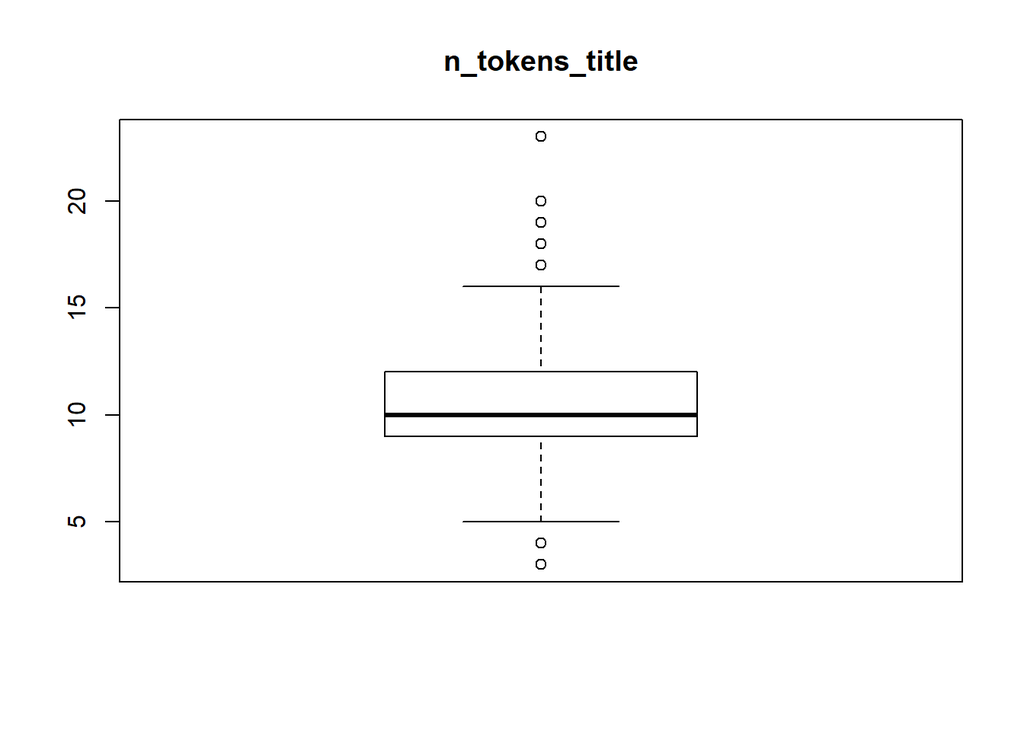

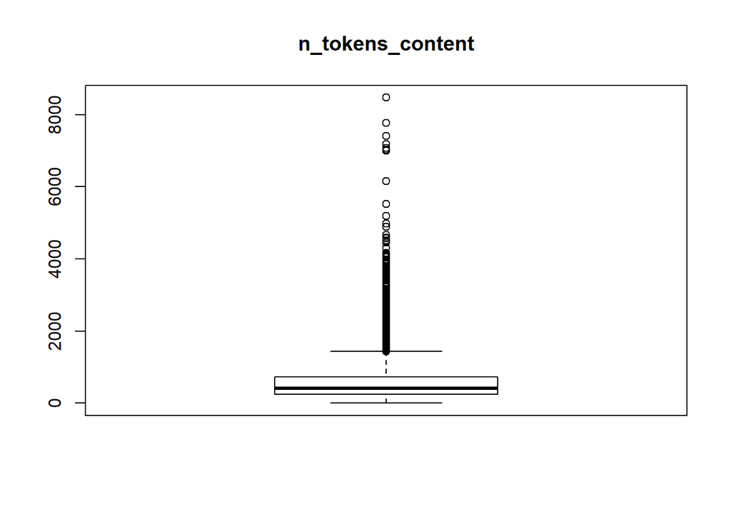

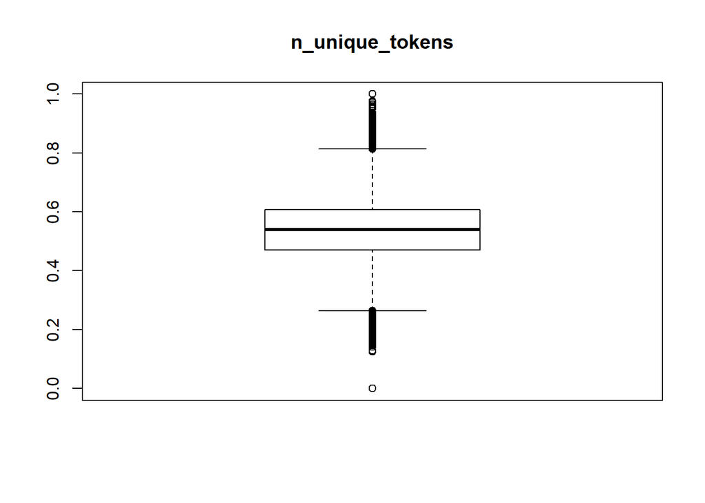

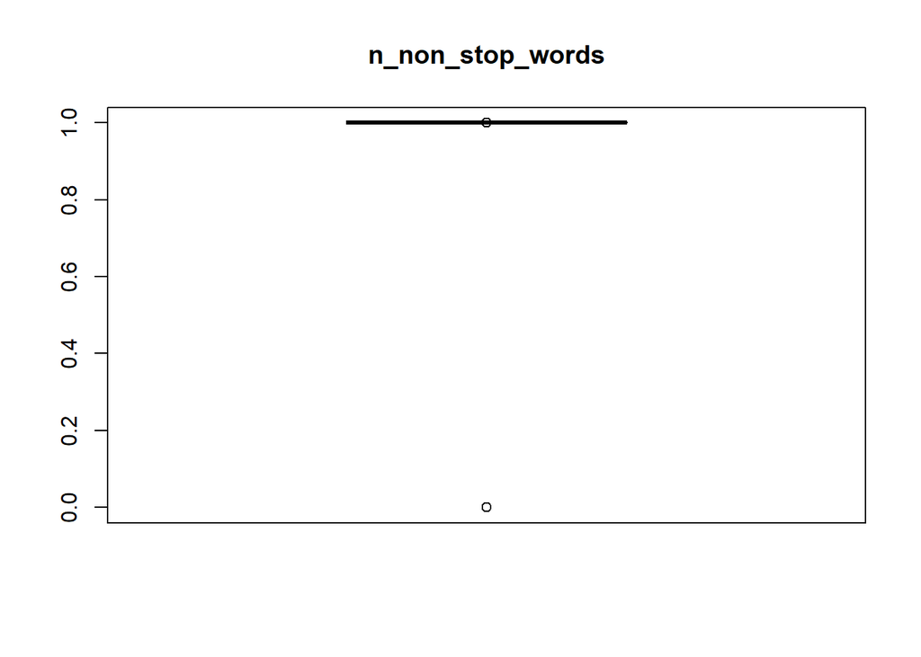

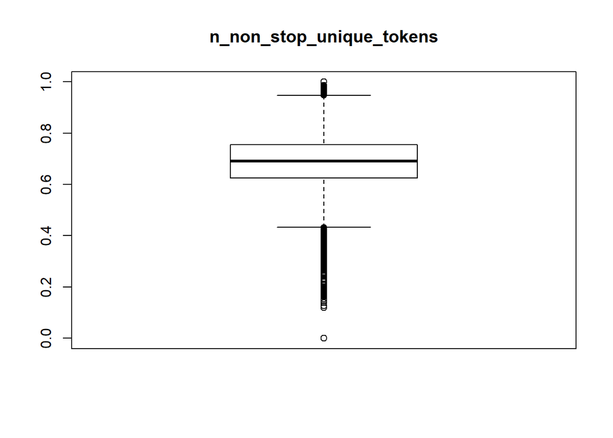

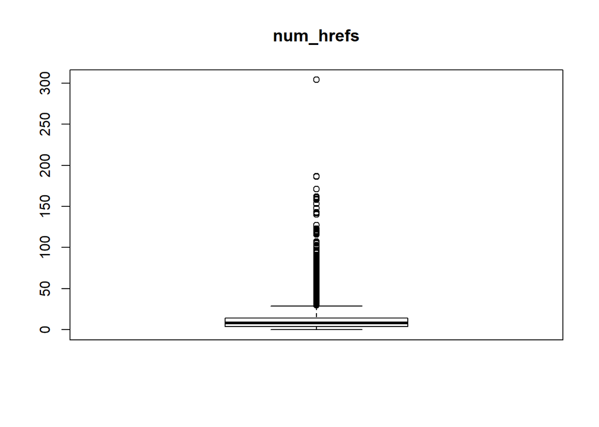

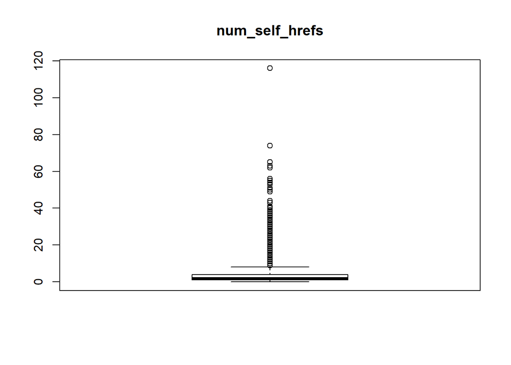

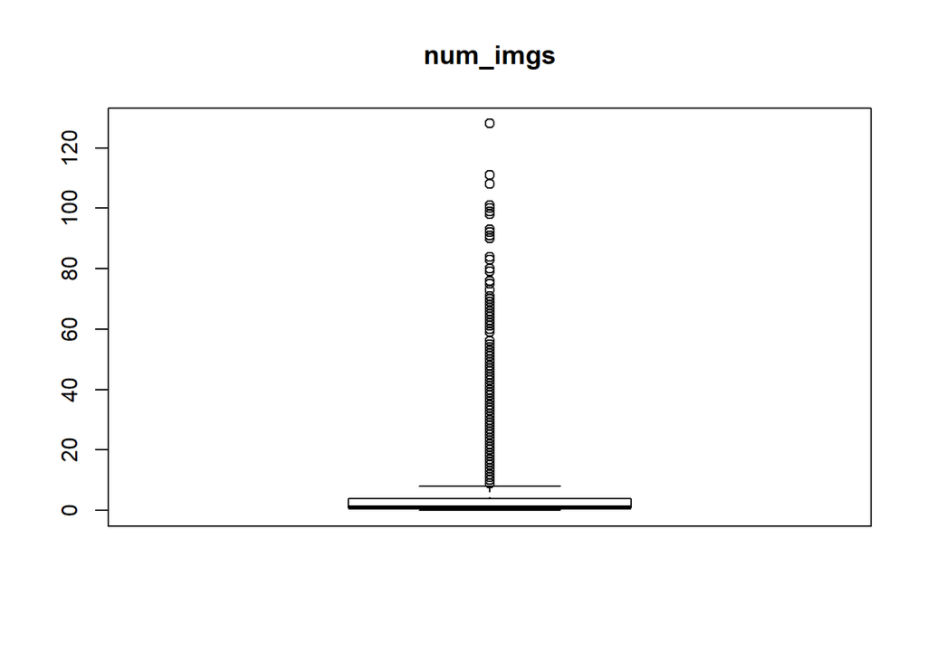

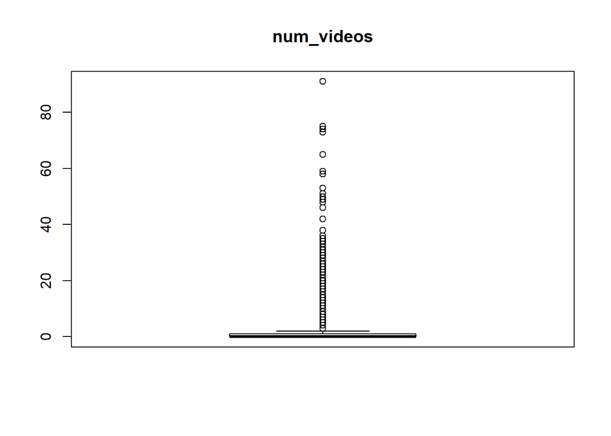

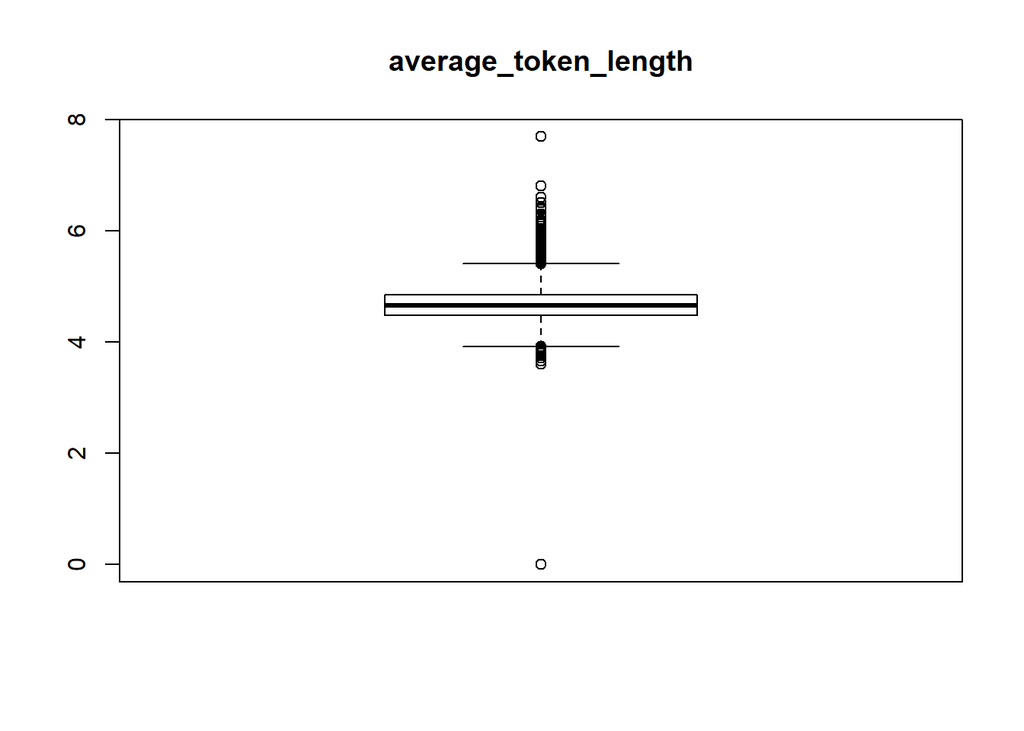

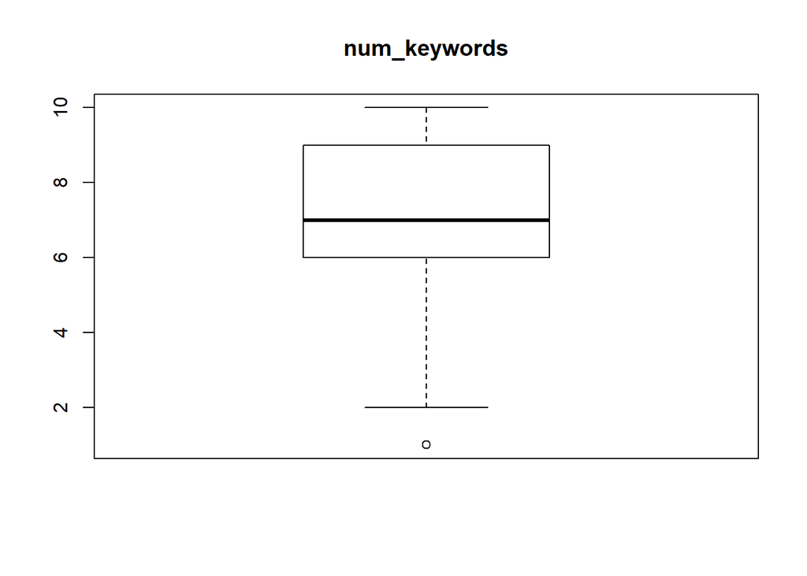

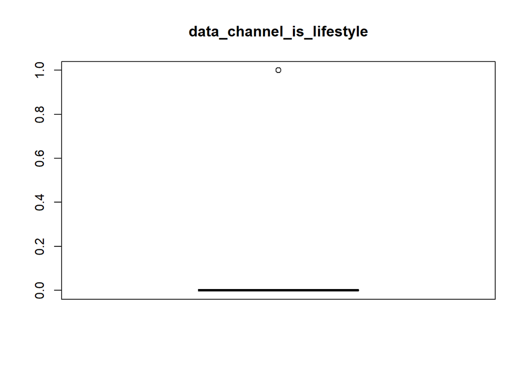

[46 more figures not shown]

```r
# Boxplots for each attribute
# par(mfrow=c(dispRow,dispCol))
for(i in 1:totAttr) {
    boxplot(x_train[,i], main=names(x_train)[i])
}
```

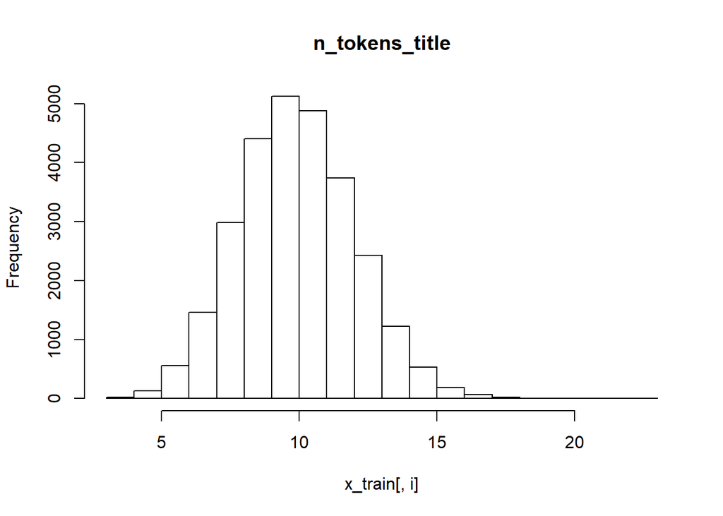

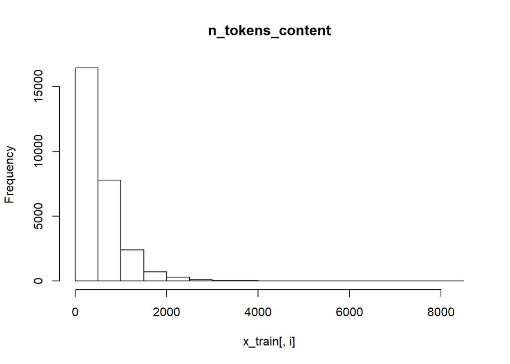

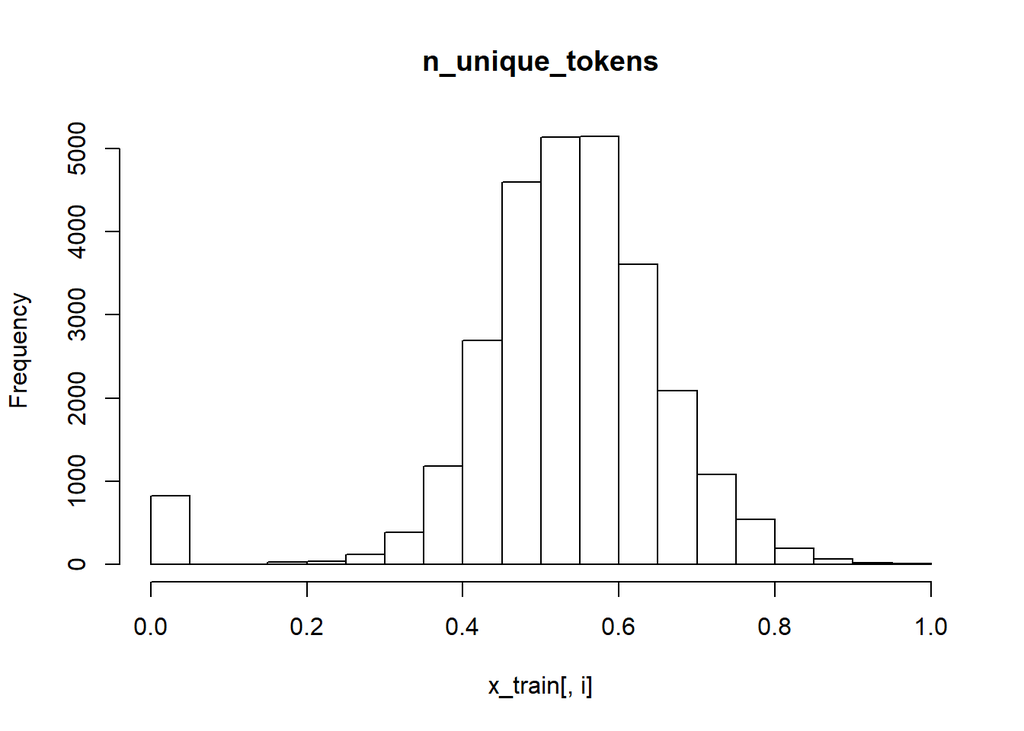

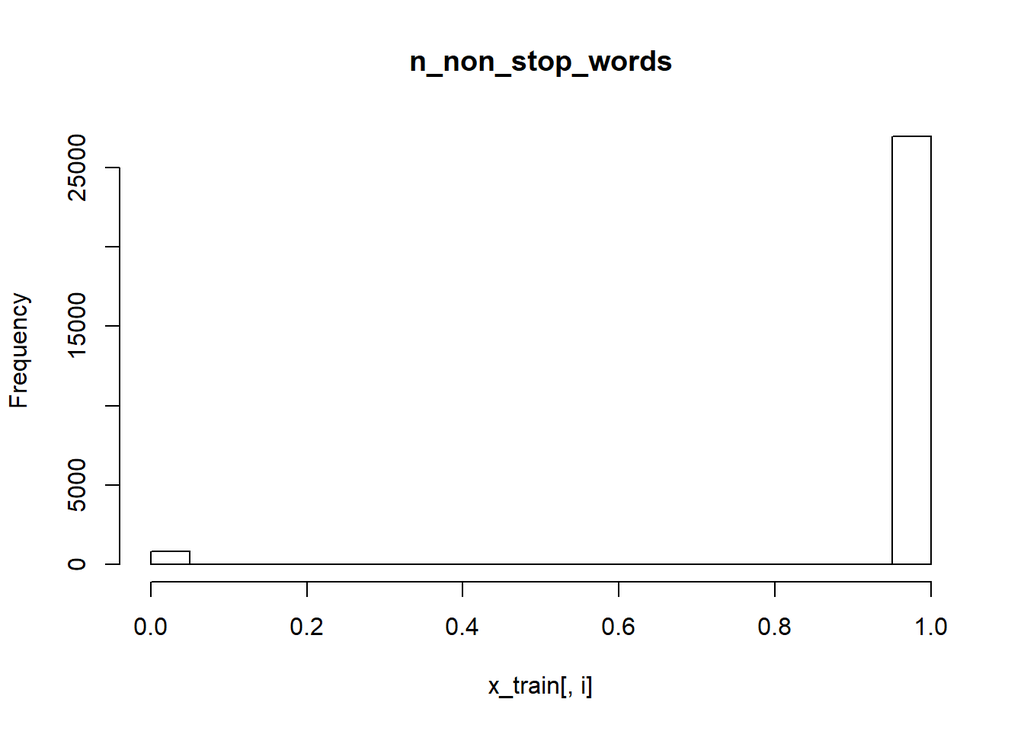

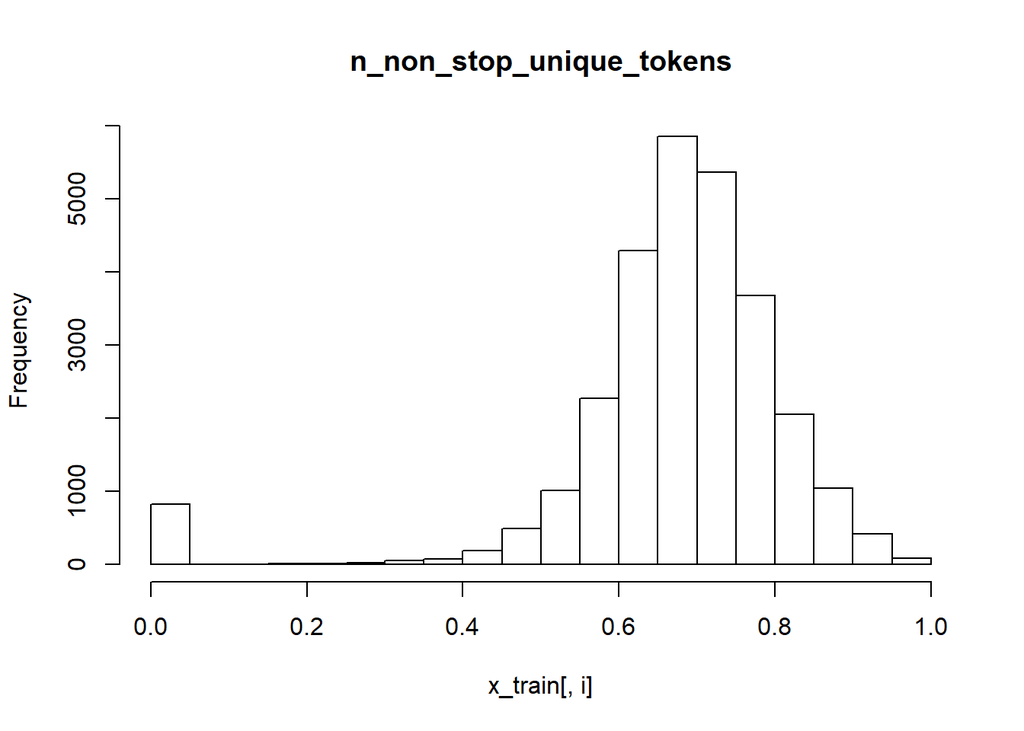

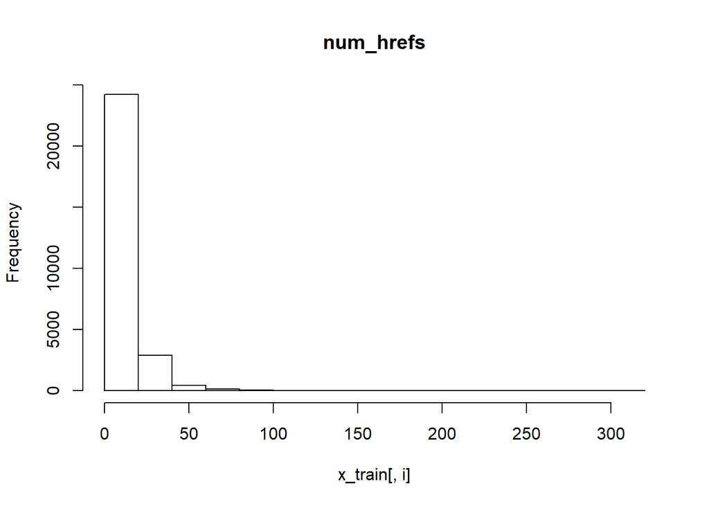

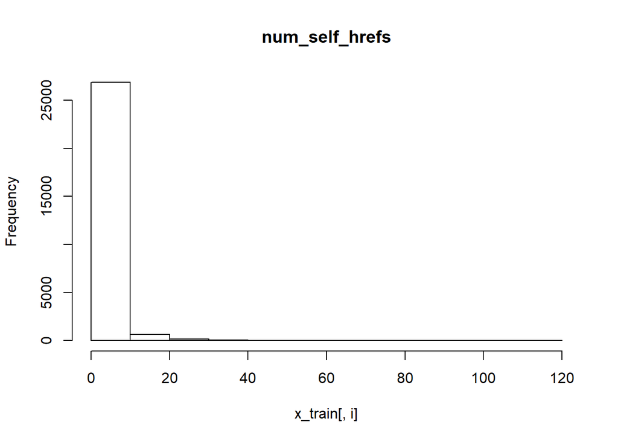

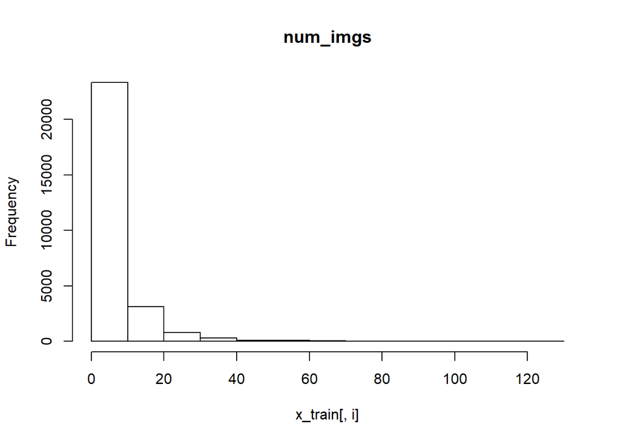

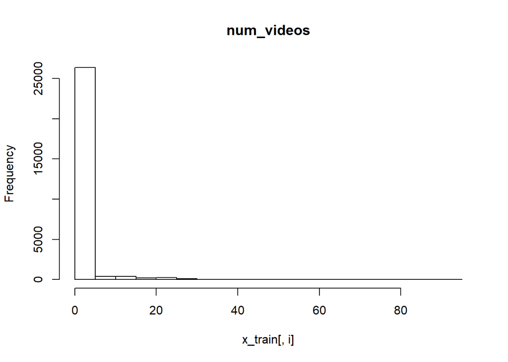

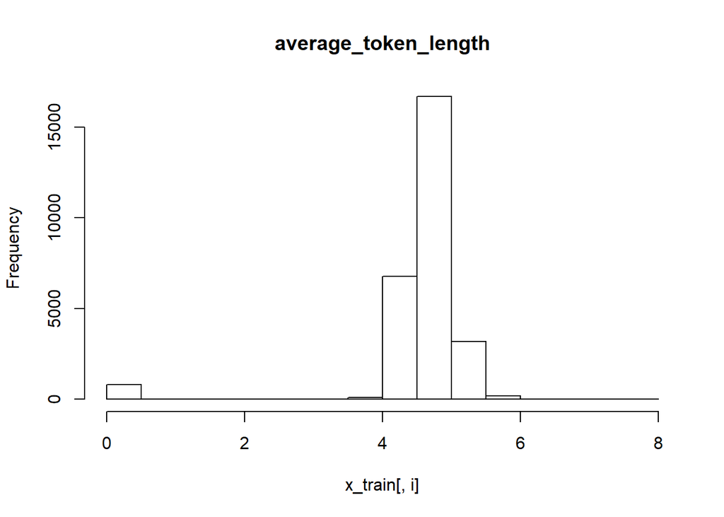

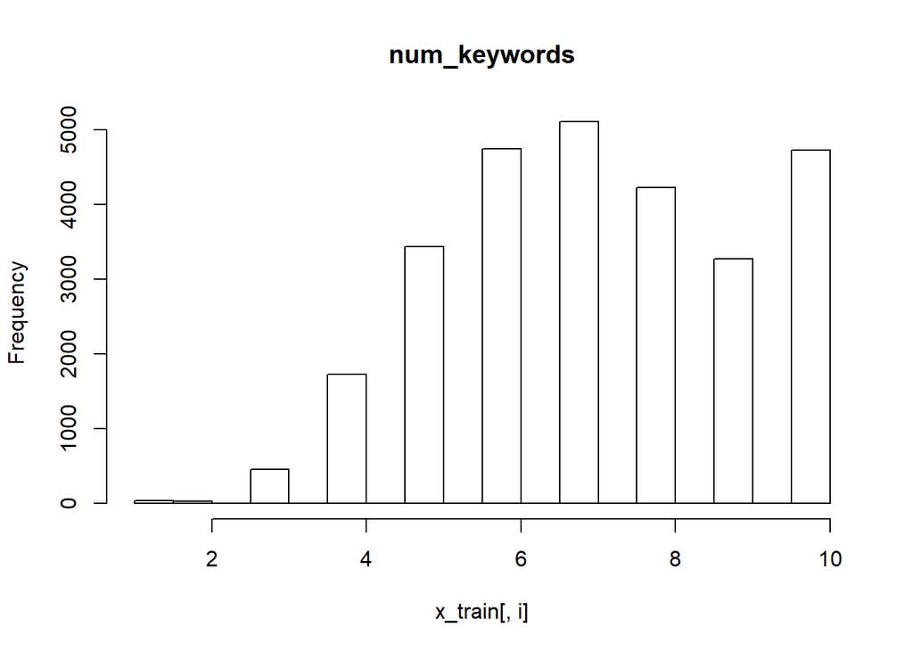

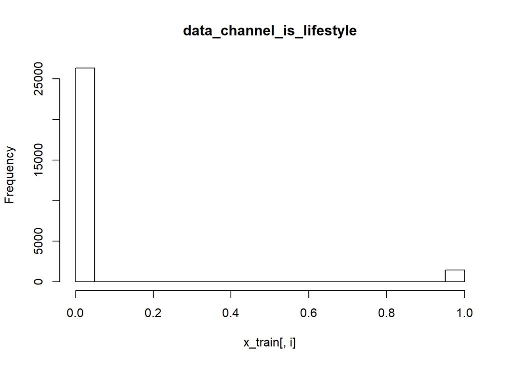

[46 more figures not shown]

```r
# Histograms each attribute
# par(mfrow=c(dispRow,dispCol))
for(i in 1:totAttr) {
    hist(x_train[,i], main=names(x_train)[i])
}
```